# LSTM_on_Donors_Choose

## DonorChoose

```
1. Download the preprocessed DonorsChoose data from here Dataset
2. Split the data into train, cv, and test
3. After step 2 you have to train 3 types of models as discussed below.
4. For all the model use 'auc' as a metric. check this for using auc as a metric. you need to print the AUC value for each epoch. Note: you should NOT use the tf.metric.auc
5. You are free to choose any number of layers/hiddden units but you have to use same type of architectures shown below.
6. You can use any one of the optimizers and choice of Learning rate and momentum, resources: cs231n class notes, cs231n class video.
7. You should Save the best model weights.
8. For all the model's use TensorBoard and plot the Metric value and Loss with epoch. While submitting, take a screenshot of plots and include those images in .ipynb notebook and PDF.
9. Use Categorical Cross Entropy as Loss to minimize.
10. try to get AUC more than 0.8 for atleast one model
```

```python
from google.colab import drive
drive.mount('/content/drive')
```

```
Go to this URL in a browser: https://accounts.google.com/o/oauth2/auth?client_id=947318989803-6bn6qk8qdgf4n4g3pfee6491hc0brc4i.apps.googleusercontent.com&redirect_uri=urn%3aietf%3awg%3aoauth%3a2.0%3aoob&response_type=code&scope=email%20https%3a%2f%2fwww.googleapis.com%2fauth%2fdocs.test%20https%3a%2…

Enter your authorization code:
··········
```

```python
#read data
import pandas as pd
preprocessdata=pd.read_csv('/content/drive/My Drive/lstm for donorchoose/preprocessed_data.csv')
preprocessdata.head(2)
```

|  | school_state | teacher_prefix | project_grade_category | teacher_number_of_previously_posted_projects | project_is_approved | clean_categories | clean_subcategories | essay | price |
| --- | --- | --- | --- | --- | --- | --- | --- | --- | --- |
| 0 | ca | mrs | grades_prek_2 | 53 | 1 | math_science | appliedsciences health_lifescience | i fortunate enough use fairy tale stem kits cl... | 725.05 |
| 1 | ut | ms | grades_3_5 | 4 | 1 | specialneeds | specialneeds | imagine 8 9 years old you third grade classroo... | 213.03 |

```python
preprocessdata.shape
```

```
(109248, 9)
```

```python
y=preprocessdata['project_is_approved']
preprocessdata.drop(['project_is_approved'], axis=1)
```

|  | school_state | teacher_prefix | project_grade_category | teacher_number_of_previously_posted_projects | clean_categories | clean_subcategories | essay | price |
| --- | --- | --- | --- | --- | --- | --- | --- | --- |
| 0 | ca | mrs | grades_prek_2 | 53 | math_science | appliedsciences health_lifescience | i fortunate enough use fairy tale stem kits cl... | 725.05 |
| 1 | ut | ms | grades_3_5 | 4 | specialneeds | specialneeds | imagine 8 9 years old you third grade classroo... | 213.03 |
| 2 | ca | mrs | grades_prek_2 | 10 | literacy_language | literacy | having class 24 students comes diverse learner... | 329.00 |
| 3 | ga | mrs | grades_prek_2 | 2 | appliedlearning | earlydevelopment | i recently read article giving students choice... | 481.04 |
| 4 | wa | mrs | grades_3_5 | 2 | literacy_language | literacy | my students crave challenge eat obstacles brea... | 17.74 |
| ... | ... | ... | ... | ... | ... | ... | ... | ... |
| 109243 | hi | mrs | grades_9_12 | 5 | health_sports | teamsports | our day starts 100 students athletes low incom... | 143.36 |
| 109244 | nm | ms | grades_prek_2 | 3 | appliedlearning | earlydevelopment other | my students range age four five years old atte... | 268.57 |
| 109245 | il | mrs | grades_3_5 | 0 | math_science | appliedsciences environmentalscience | we title 1 school 650 total students our eleme... | 399.00 |
| 109246 | hi | mrs | grades_9_12 | 1 | math_science | health_lifescience | i teach many different types students my class... | 287.73 |
| 109247 | ca | mrs | grades_prek_2 | 2 | literacy_language | literacy literature_writing | my first graders eager learn world around they... | 5.50 |

109248 rows × 8 columns

```python
# https://scikit-learn.org/stable/modules/generated/sklearn.preprocessing.OneHotEncoder.html
import tensorflow as tf
from sklearn.preprocessing import LabelEncoder
# creating instance of labelencoder
labelencoder = LabelEncoder()
# Assigning numerical values and storing in another column
y2= labelencoder.fit_transform(y)

y2=tf.keras.utils.to_categorical(y2, 2)
```

```python
y2
```

```
array([[0., 1.],
       [0., 1.],
       [0., 1.],
       ...,
       [0., 1.],
       [0., 1.],
       [0., 1.]], dtype=float32)
```

Preprocess Text and categorical features before splitting data

```python
#preprocess text
preprocessdata['essay'].values[90]
print("*"*50)
print(preprocessdata['essay'].values[1000])
print("*"*50)
print(preprocessdata['essay'].values[10000])
print("*"*50)
print(preprocessdata['essay'].values[90000])
```

```
life moves pretty fast if not stop look around awhile could miss movie ferris bueller day off think back remember grandparents how amazing would able flip book see day lives my second graders voracious readers they love read fiction nonfiction books their favorite characters include pete cat fly guy…
take minute think like work do prefer sit chair table would rather curl couch book computer lap everyone prefers learn work different ways kindergarten 1st grade students way my students 5 6 year olds eager come school learn many kindergarten students never attended school first day step classroom t…
i 18 inquisitive learners pre k classroom my students learn using senses i try change materials different areas centers classroom my students enjoy opportunities learn play social interactions developmental appropriate materials my students inquisitive minds love science science related activities e…
```

As per above data in essay, text looks clean and does not require any preprocessing. But seems to contain sme stop words.

```python
stopwords= ['i', 'me', 'my', 'myself', 'we', 'our', 'ours', 'ourselves', 'you', "you're", "you've",\
            "you'll", "you'd", 'your', 'yours', 'yourself', 'yourselves', 'he', 'him', 'his', 'himself', \
            'she', "she's", 'her', 'hers', 'herself', 'it', "it's", 'its', 'itself', 'they', 'them', 'their',\
            'theirs', 'themselves', 'what', 'which', 'who', 'whom', 'this', 'that', "that'll", 'these', 'those', \
            'am', 'is', 'are', 'was', 'were', 'be', 'been', 'being', 'have', 'has', 'had', 'having', 'do', 'does', \
            'did', 'doing', 'a', 'an', 'the', 'and', 'but', 'if', 'or', 'because', 'as', 'until', 'while', 'of', \
            'at', 'by', 'for', 'with', 'about', 'against', 'between', 'into', 'through', 'during', 'before', 'after',\
            'above', 'below', 'to', 'from', 'up', 'down', 'in', 'out', 'on', 'off', 'over', 'under', 'again', 'further',\
            'then', 'once', 'here', 'there', 'when', 'where', 'why', 'how', 'all', 'any', 'both', 'each', 'few', 'more',\
            'most', 'other', 'some', 'such', 'only', 'own', 'same', 'so', 'than', 'too', 'very', \
            's', 't', 'can', 'will', 'just', 'don', "don't", 'should', "should've", 'now', 'd', 'll', 'm', 'o', 're', \
            've', 'y', 'ain', 'aren', "aren't", 'couldn', "couldn't", 'didn', "didn't", 'doesn', "doesn't", 'hadn',\
            "hadn't", 'hasn', "hasn't", 'haven', "haven't", 'isn', "isn't", 'ma', 'mightn', "mightn't", 'mustn',\
            "mustn't", 'needn', "needn't", 'shan', "shan't", 'shouldn', "shouldn't", 'wasn', "wasn't", 'weren', "weren't", \
            'won', "won't", 'wouldn', "wouldn't"]
```

```python
# https://stackoverflow.com/a/47091490/4084039
import re

def decontracted(phrase):
    # specific
    phrase = re.sub(r"won't", "will not", phrase)
    phrase = re.sub(r"can\'t", "can not", phrase)

    # general
    phrase = re.sub(r"n\'t", " not", phrase)
    phrase = re.sub(r"\'re", " are", phrase)
    phrase = re.sub(r"\'s", " is", phrase)
    phrase = re.sub(r"\'d", " would", phrase)
    phrase = re.sub(r"\'ll", " will", phrase)
    phrase = re.sub(r"\'t", " not", phrase)
    phrase = re.sub(r"\'ve", " have", phrase)
    phrase = re.sub(r"\'m", " am", phrase)
    return phrase
```

```python
def preprocess_text(text_data):
    preprocessed_text = []
    # tqdm is for printing the status bar
    for sentance in (text_data):
        sent = decontracted(sentance)
        sent = sent.replace('\\r', ' ')
        sent = sent.replace('\\n', ' ')
        sent = sent.replace('\\"', ' ')
        sent = re.sub('[^A-Za-z0-9]+', ' ', sent)
        # https://gist.github.com/sebleier/554280
        sent = ' '.join(e for e in sent.split() if e.lower() not in stopwords)
        preprocessed_text.append(sent.lower().strip())
    return preprocessed_text
```

```python
#https://stackoverflow.com/questions/33098040/how-to-use-word-tokenize-in-data-frame
import nltk
nltk.download('punkt')
```

```
True
```

```python
preprocessdata['tokenized_sents'] = preprocessdata.apply(lambda row: nltk.word_tokenize(row['essay']), axis=1)
preprocessdata['sents_length'] = preprocessdata.apply(lambda row: len(row['tokenized_sents']), axis=1)
```

```python
max(preprocessdata['sents_length'])
```

```
339
```

```python
from sklearn.model_selection import train_test_split
X_train, X_test, y_train, y_test = train_test_split(preprocessdata, y , stratify=y,test_size=0.3)
X_train, X_cv, y_train, y_cv = train_test_split(X_train, y_train, test_size=0.30, stratify=y_train)
```

```python
X_train['essay'] = preprocess_text(X_train['essay'].values)
X_test['essay'] = preprocess_text(X_test['essay'].values)
X_cv['essay'] = preprocess_text(X_cv['essay'].values)
```

```python
#get padded sequence of length 339
#https://machinelearningmastery.com/prepare-text-data-deep-learning-keras/
import keras
from keras.preprocessing.text import Tokenizer
import tensorflow as tf


t=tf.keras.preprocessing.text.Tokenizer(
    num_words=350,
    filters='!"#$%&()*+,-./:;<=>?@[\\]^_`{|}~\t\n',
    lower=True,
    split=" ",
    char_level=False,
    oov_token=None
)

t.fit_on_texts(X_train['essay'])

vocab_size = len(t.word_index) + 1
# fit the tokenizer on the documents
encoded_docs_train=t.texts_to_sequences(X_train['essay'])
encoded_docs_test=t.texts_to_sequences(X_test['essay'])
encoded_docs_cv=t.texts_to_sequences(X_cv['essay'])

max_length = 350
padded_docs_tr = tf.keras.preprocessing.sequence.pad_sequences(encoded_docs_train, maxlen=max_length, padding='post')
padded_docs_ts = tf.keras.preprocessing.sequence.pad_sequences(encoded_docs_test, maxlen=max_length, padding='post')
padded_docs_cv = tf.keras.preprocessing.sequence.pad_sequences(encoded_docs_cv, maxlen=max_length, padding='post')
#t.texts_to_matrix(dfnew['Model_Column'], mode='tfidf') # can be used  without using pretrained gloves
```

```python
#using pretrain word embeddings
#load the entire GloVe word embedding file into memory as a dictionary of word to embedding array.
import numpy as np
embeddings_index = dict()
f = open('/content/drive/My Drive/CNN_with_textdata-20200413T094931Z-001/CNN_with_textdata/glove.6B/glove.6B.100d.txt')
for line in f:
	values = line.split()
	word = values[0]
	coefs = np.asarray(values[1:], dtype='float32')
	embeddings_index[word] = coefs
f.close()
print('Loaded %s word vectors.' % len(embeddings_index))
```

```
Loaded 400000 word vectors.
```

```python
# create a weight matrix for words in training docs
embedding_matrix = np.zeros((vocab_size, 100))
for word, i in t.word_index.items():
	embedding_vector = embeddings_index.get(word)
	if embedding_vector is not None:
		embedding_matrix[i] = embedding_vector
```

```python
#get max lengths for all categorical data
preprocessdata['tokenized_sents1'] = preprocessdata.apply(lambda row: nltk.word_tokenize(row['school_state']), axis=1)
preprocessdata['sents_length1'] = preprocessdata.apply(lambda row: len(row['tokenized_sents1']), axis=1)

preprocessdata['tokenized_sents2'] = preprocessdata.apply(lambda row: nltk.word_tokenize(row['teacher_prefix']), axis=1)
preprocessdata['sents_length2'] = preprocessdata.apply(lambda row: len(row['tokenized_sents2']), axis=1)

preprocessdata['tokenized_sents3'] = preprocessdata.apply(lambda row: nltk.word_tokenize(row['project_grade_category']), axis=1)
preprocessdata['sents_length3'] = preprocessdata.apply(lambda row: len(row['tokenized_sents3']), axis=1)


preprocessdata['tokenized_sents4'] = preprocessdata.apply(lambda row: nltk.word_tokenize(row['clean_categories']), axis=1)
preprocessdata['sents_length4'] = preprocessdata.apply(lambda row: len(row['tokenized_sents4']), axis=1)

preprocessdata['tokenized_sents5'] = preprocessdata.apply(lambda row: nltk.word_tokenize(row['clean_subcategories']), axis=1)
preprocessdata['sents_length5'] = preprocessdata.apply(lambda row: len(row['tokenized_sents5']), axis=1)

print(max(preprocessdata['sents_length1']))
print(max(preprocessdata['sents_length2']))
print(max(preprocessdata['sents_length3']))
print(max(preprocessdata['sents_length4']))
print(max(preprocessdata['sents_length5']))
```

```
1
1
1
3
3
```

```python
#get embedding weights for all catgrical data
#school_state

t1=Tokenizer()
t2=Tokenizer()
t3=Tokenizer()
t4=Tokenizer()
t5=Tokenizer()

t1.fit_on_texts(X_train['school_state'])

vocab_size_school_state = len(t1.word_index) + 1
# fit the tokenizer on the documents
print(t1.word_index)
encoded_docs_tr_sc=t.texts_to_sequences(X_train['school_state'])
encoded_docs_ts_sc=t.texts_to_sequences(X_test['school_state'])
encoded_docs_cv_sc=t.texts_to_sequences(X_cv['school_state'])
max_length = 1
padded_state_tr = keras.preprocessing.sequence.pad_sequences(encoded_docs_tr_sc, maxlen=max_length, padding='post')
padded_state_ts = keras.preprocessing.sequence.pad_sequences(encoded_docs_ts_sc, maxlen=max_length, padding='post')
padded_state_cv = keras.preprocessing.sequence.pad_sequences(encoded_docs_cv_sc, maxlen=max_length, padding='post')


# # create a weight matrix for words in training docs
# embedding_matrix_state = np.zeros((vocab_size_school_state, 100))
# for word, i in t.word_index.items():
# 	embedding_vector = embeddings_index.get(word)
# 	if embedding_vector is not None:
# 		embedding_matrix_state[i] = embedding_vector
######################################################
```

```
{'ca': 1, 'tx': 2, 'ny': 3, 'fl': 4, 'nc': 5, 'il': 6, 'ga': 7, 'sc': 8, 'mi': 9, 'pa': 10, 'in': 11, 'mo': 12, 'oh': 13, 'ma': 14, 'la': 15, 'wa': 16, 'nj': 17, 'ok': 18, 'az': 19, 'va': 20, 'wi': 21, 'al': 22, 'tn': 23, 'ut': 24, 'ct': 25, 'md': 26, 'nv': 27, 'ms': 28, 'ky': 29, 'or': 30, 'mn': 31…
```

```python
#teacher_prefix
t2.fit_on_texts(X_train['teacher_prefix'])

vocab_size_teacher = len(t2.word_index) + 1
print(t2.word_index)
# fit the tokenizer on the documents
encoded_docs_teacher_tr=t.texts_to_sequences(X_train['teacher_prefix'])
encoded_docs_teacher_ts=t.texts_to_sequences(X_test['teacher_prefix'])
encoded_docs_teacher_cv=t.texts_to_sequences(X_cv['teacher_prefix'])
max_length =1
padded_docs_teacher_tr= keras.preprocessing.sequence.pad_sequences(encoded_docs_teacher_tr, maxlen=max_length, padding='post')
padded_docs_teacher_ts= keras.preprocessing.sequence.pad_sequences(encoded_docs_teacher_ts, maxlen=max_length, padding='post')
padded_docs_teacher_cv= keras.preprocessing.sequence.pad_sequences(encoded_docs_teacher_cv, maxlen=max_length, padding='post')


############################################
#project_grade_category
t3.fit_on_texts(X_train['project_grade_category'])

vocab_size_grade_cat= len(t3.word_index) + 1
# fit the tokenizer on the documents
print(t3.word_index)
encoded_docs_grcat_tr=t.texts_to_sequences(X_train['project_grade_category'])
encoded_docs_grcat_ts=t.texts_to_sequences(X_test['project_grade_category'])
encoded_docs_grcat_cv=t.texts_to_sequences(X_cv['project_grade_category'])
max_length = 1
padded_docs_grade_cat_tr = keras.preprocessing.sequence.pad_sequences(encoded_docs_grcat_tr, maxlen=max_length, padding='post')
padded_docs_grade_cat_ts = keras.preprocessing.sequence.pad_sequences(encoded_docs_grcat_ts, maxlen=max_length, padding='post')
padded_docs_grade_cat_cv = keras.preprocessing.sequence.pad_sequences(encoded_docs_grcat_cv, maxlen=max_length, padding='post')



##############################################################
#clean_categories
t4.fit_on_texts(X_train['clean_categories'])

vocab_size_clean_cat = len(t4.word_index) + 1
# fit the tokenizer on the documents
print(t4.word_index)
encoded_docs_clcat_tr=t.texts_to_sequences(X_train['clean_categories'])
encoded_docs_clcat_ts=t.texts_to_sequences(X_test['clean_categories'])
encoded_docs_clcat_cv=t.texts_to_sequences(X_cv['clean_categories'])
max_length = 3
padded_docs_clean_cat_tr = keras.preprocessing.sequence.pad_sequences(encoded_docs_clcat_tr, maxlen=max_length, padding='post')
padded_docs_clean_cat_ts = keras.preprocessing.sequence.pad_sequences(encoded_docs_clcat_ts, maxlen=max_length, padding='post')
padded_docs_clean_cat_cv = keras.preprocessing.sequence.pad_sequences(encoded_docs_clcat_cv, maxlen=max_length, padding='post')



#################################################################
#clean_subcategories
t5.fit_on_texts(X_train['clean_subcategories'])

vocab_size_clean_subcat = len(t5.word_index) + 1
print(t5.word_index)
# fit the tokenizer on the documents
encoded_docs_subcat_tr=t.texts_to_sequences(X_train['clean_subcategories'])
encoded_docs_subcat_ts=t.texts_to_sequences(X_test['clean_subcategories'])
encoded_docs_subcat_cv=t.texts_to_sequences(X_cv['clean_subcategories'])
max_length = 3
padded_docs_clean_subcat_tr = keras.preprocessing.sequence.pad_sequences(encoded_docs_subcat_tr, maxlen=max_length, padding='post')
padded_docs_clean_subcat_ts = keras.preprocessing.sequence.pad_sequences(encoded_docs_subcat_ts, maxlen=max_length, padding='post')
padded_docs_clean_subcat_cv = keras.preprocessing.sequence.pad_sequences(encoded_docs_subcat_cv, maxlen=max_length, padding='post')
```

```
{'mrs': 1, 'ms': 2, 'mr': 3, 'teacher': 4, 'dr': 5}
{'grades': 1, 'prek': 2, '2': 3, '3': 4, '5': 5, '6': 6, '8': 7, '9': 8, '12': 9}
{'literacy': 1, 'language': 2, 'math': 3, 'science': 4, 'health': 5, 'sports': 6, 'specialneeds': 7, 'appliedlearning': 8, 'music': 9, 'arts': 10, 'history': 11, 'civics': 12, 'warmth': 13, 'care': 14, 'hunger': 15}
{'literacy': 1, 'mathematics': 2, 'literature': 3, 'writing': 4, 'health': 5, 'specialneeds': 6, 'appliedsciences': 7, 'wellness': 8, 'visualarts': 9, 'environmentalscience': 10, 'gym': 11, 'fitness': 12, 'esl': 13, 'earlydevelopment': 14, 'lifescience': 15, 'music': 16, 'history': 17, 'geography': …
```

Preprocess numerical data

```python
from sklearn.preprocessing import Normalizer

normalizer = Normalizer()
price_normalized=normalizer.fit(X_train['price'].values.reshape(1,-1))


price_train = normalizer.transform(X_train['price'].values.reshape(1,-1)).T
price_test = normalizer.transform(X_test['price'].values.reshape(1,-1)).T
price_cv = normalizer.transform(X_cv['price'].values.reshape(1,-1)).T
```

```python
normalizer2 = Normalizer()
previously_posted_normalized=normalizer2.fit(X_train['teacher_number_of_previously_posted_projects'].values.reshape(1,-1))


previously_posted_train = normalizer2.transform(X_train['teacher_number_of_previously_posted_projects'].values.reshape(1,-1)).T
previously_posted_test = normalizer2.transform(X_test['teacher_number_of_previously_posted_projects'].values.reshape(1,-1)).T
previously_posted_cv = normalizer2.transform(X_cv['teacher_number_of_previously_posted_projects'].values.reshape(1,-1)).T
```

```python
numericals_tr=np.concatenate((price_train,previously_posted_train),axis=1)
numericals_ts=np.concatenate((price_test,previously_posted_test),axis=1)
numericals_cv=np.concatenate((price_cv,previously_posted_cv),axis=1)
```

```python
print(numericals_tr.shape)
print(padded_docs_clean_subcat_tr.shape)
print(padded_docs_clean_cat_tr.shape)
print(padded_docs_grade_cat_tr.shape)
print(padded_docs_teacher_tr.shape)
print(padded_state_tr.shape)
print(padded_docs_tr.shape)
```

```
(53531, 2)
(53531, 3)
(53531, 3)
(53531, 1)
(53531, 1)
(53531, 1)
(53531, 350)
```

```python
# #now combine all padded docs into one data for train,test and cv

# Padded_data_tr=np.concatenate((padded_docs_tr,padded_state_tr,padded_docs_teacher_tr,padded_docs_grade_cat_tr,padded_docs_clean_cat_tr,padded_docs_clean_subcat_tr,numericals_tr),axis=1)
# Padded_data_ts=np.concatenate((padded_docs_ts,padded_state_ts,padded_docs_teacher_ts,padded_docs_grade_cat_ts,padded_docs_clean_cat_ts,padded_docs_clean_subcat_ts,numericals_ts),axis=1)
# Padded_data_cv=np.concatenate((padded_docs_cv,padded_state_cv,padded_docs_teacher_cv,padded_docs_grade_cat_cv,padded_docs_clean_cat_cv,padded_docs_clean_subcat_cv,numericals_cv),axis=1)


#now combine all padded docs into one data for train,test and cv

Padded_data_tr=np.hstack((padded_docs_tr,padded_state_tr,padded_docs_teacher_tr,padded_docs_grade_cat_tr,padded_docs_clean_cat_tr,padded_docs_clean_subcat_tr,numericals_tr))
Padded_data_ts=np.hstack((padded_docs_ts,padded_state_ts,padded_docs_teacher_ts,padded_docs_grade_cat_ts,padded_docs_clean_cat_ts,padded_docs_clean_subcat_ts,numericals_ts))
Padded_data_cv=np.hstack((padded_docs_cv,padded_state_cv,padded_docs_teacher_cv,padded_docs_grade_cat_cv,padded_docs_clean_cat_cv,padded_docs_clean_subcat_cv,numericals_cv))
```

```python
from keras.utils import np_utils
y_train1 = np_utils.to_categorical(y_train, 2)
y_test1 = np_utils.to_categorical(y_test, 2)
y_cv1 = np_utils.to_categorical(y_cv, 2)
```

```python
print(Padded_data_tr.shape),print(Padded_data_ts.shape),print(Padded_data_cv.shape),print(y_train1.shape),print(y_test1.shape),print(y_cv1.shape)
```

[output not shown]

```python
y_train1
```

```
array([[0., 1.],
       [1., 0.],
       [0., 1.],
       ...,
       [0., 1.],
       [0., 1.],
       [0., 1.]], dtype=float32)
```

### Model-1

Build and Train deep neural network as shown below

[figure not shown]

ref: https://i.imgur.com/w395Yk9.png

- **Input_seq_total_text_data** --- You have to give Total text data columns. After this use the Embedding layer to get word vectors. Use given predefined glove word vectors, don't train any word vectors. After this use LSTM and get the LSTM output and Flatten that output.
- **Input_school_state** --- Give 'school_state' column as input to embedding layer and Train the Keras Embedding layer.
- **Project_grade_category** --- Give 'project_grade_category' column as input to embedding layer and Train the Keras Embedding layer.
- **Input_clean_categories** --- Give 'input_clean_categories' column as input to embedding layer and Train the Keras Embedding layer.
- **Input_clean_subcategories** --- Give 'input_clean_subcategories' column as input to embedding layer and Train the Keras Embedding layer.
- **Input_clean_subcategories** --- Give 'input_teacher_prefix' column as input to embedding layer and Train the Keras Embedding layer.
- **Input_remaining_teacher_number_of_previously_posted_projects._resource_summary_contains_numerical_digits._price._quantity** ---concatenate remaining columns and add a Dense layer after that.
- For LSTM, you can choose your sequence padding methods on your own or you can train your LSTM without padding, there is no restriction on that.

Below is an example of embedding layer for a categorical columns. In below code all are dummy values, we gave only for referance.

```python
# https://stats.stackexchange.com/questions/270546/how-does-keras-embedding-layer-work
Input_seq_total_text_data = Input(shape=(n,))
embedding = Embedding(no_1, no_2, input_length=n)(input_layer)
flatten = Flatten()(embedding)
```

### 1. Go through this blog, if you have any doubt on using predefined Embedding values in Embedding layer - https://machinelearningmastery.com/use-word-embedding-layers-deep-learning-keras/

### 2. Please go through this link https://keras.io/getting-started/functional-api-guide/ and check the 'Multi-input and multi-output models' then you will get to know how to give multiple inputs.

```python
from keras import optimizers
from keras.layers import Dense,Input,Conv2D,MaxPool2D,Activation,Dropout,Flatten,MaxPooling2D,GlobalAveragePooling2D,Embedding,Conv1D,Concatenate,MaxPooling1D,LSTM,BatchNormalization
from keras.models import Model,Sequential
import random as rn
import tensorflow as tf
from sklearn.metrics import f1_score
import keras
# import tensorflow_addons as tfa
from keras import regularizers
```

Building Model1

```python
vocab_size_grade_cat
```

[output not shown]

```python
#saving wts
# https://github.com/keras-team/keras/blob/master/examples/pretrained_word_embeddings.py
# https://machinelearningmastery.com/use-word-embedding-layers-deep-learning-keras/
from keras.callbacks import ModelCheckpoint


filepath="/content/drive/My Drive/lstm for donorchoose/model1weights.hdf5"
checkpoint = ModelCheckpoint(filepath=filepath,monitor='val_auc',verbose=1,save_best_only=True,mode='max'
                             ,save_weights_only=True)
```

```python
from keras.callbacks import EarlyStopping
earlystop = EarlyStopping(monitor='val_auc', mode='max', patience=5, verbose=1)
```

```python
%load_ext tensorboard
```

```python
# input_dim=Padded_data_tr.shape[1]
Input_seq_total_text_data = Input(shape=(350,))
embeddinglayer = Embedding(vocab_size, 100, weights=[embedding_matrix], input_length=350, trainable=False)(Input_seq_total_text_data)
# masklayer=tf.keras.layers.Masking(mask_value=0.0)(embeddinglayer)
lstm=LSTM(128,return_sequences=True)(embeddinglayer)
flatten = Flatten()(lstm)

Input_school_state = Input(shape=(padded_state_tr.shape[1],))
embedding2 = Embedding(vocab_size_school_state, 25, input_length=1)(Input_school_state)
flatten2 = Flatten()(embedding2)

# Project_grade_category = Input(shape=(padded_docs_grade_cat_tr.shape[1],))
Project_grade_category = Input(shape=(1,))
embedding3 = Embedding(vocab_size_grade_cat, 10, input_length=1)(Project_grade_category)
flatten3 = Flatten()(embedding3)

Input_clean_categories  = Input(shape=(padded_docs_clean_cat_tr.shape[1],))
embedding4= Embedding(vocab_size_clean_cat, 10, input_length=3)(Input_clean_categories)
flatten4 = Flatten()(embedding4)

Input_clean_subcategories = Input(shape=(padded_docs_clean_subcat_tr.shape[1],))
embedding5 = Embedding(vocab_size_clean_subcat, 15, input_length=3)(Input_clean_subcategories)
flatten5 = Flatten()(embedding5)

Input_teacher_prefix = Input(shape=(padded_docs_teacher_tr.shape[1],))
embedding6 = Embedding(vocab_size_teacher, 10, input_length=1)(Input_teacher_prefix)
flatten6 = Flatten()(embedding6)

Input_remaining_teacher_number_of_previously_posted_projects_price = Input(shape=(2,))
dense_numerical = Dense(150,activation="relu")(Input_remaining_teacher_number_of_previously_posted_projects_price)

concatenate_layer=Concatenate(axis=1)([flatten,flatten2,flatten3,flatten4,flatten5,flatten6,dense_numerical])
Dense_layer1 = Dense(128,activation="relu",kernel_initializer="he_normal",kernel_regularizer=regularizers.l2(0.001))(concatenate_layer)
Droplayer1=Dropout(0.5)(Dense_layer1)
Dense_layer2 = Dense(256,activation="relu",kernel_initializer="he_normal",kernel_regularizer=regularizers.l2(0.001))(Droplayer1)
Droplayer2=Dropout(0.5)(Dense_layer2)
Dense_layer3 = Dense(64,activation="relu",kernel_initializer="he_normal",kernel_regularizer=regularizers.l2(0.001))(Droplayer2)
Droplayer3=Dropout(0.3)(Dense_layer3)
norm = BatchNormalization()(Dense_layer3)
output = Dense(2, activation='softmax', name='output')(norm)
# Model1=Model((input,output))
Model1 = Model(inputs=[Input_seq_total_text_data,Input_school_state,Project_grade_category,Input_clean_categories,Input_clean_subcategories,Input_teacher_prefix,Input_remaining_teacher_number_of_previously_posted_projects_price],outputs=output)
#
Model1.summary()
```

```
Model: "model_2"
__________________________________________________________________________________________________
Layer (type)                    Output Shape         Param #     Connected to
==================================================================================================
input_8 (InputLayer)            (None, 350)          0
__________________________________________________________________________________________________
embedding_7 (Embedding)         (None, 350, 100)     4246400     input_8[0][0]
__________________________________________________________________________________________________
input_9 (InputLayer)            (None, 1)            0
__________________________________________________________________________________________________
input_10 (InputLayer)           (None, 1)            0
__________________________________________________________________________________________________
input_11 (InputLayer)           (None, 3)            0
__________________________________________________________________________________________________
input_12 (InputLayer)           (None, 3)            0
__________________________________________________________________________________________________
input_13 (InputLayer)           (None, 1)            0
__________________________________________________________________________________________________
lstm_2 (LSTM)                   (None, 350, 128)     117248      embedding_7[0][0]
__________________________________________________________________________________________________
embedding_8 (Embedding)         (None, 1, 25)        1300        input_9[0][0]
__________________________________________________________________________________________________
embedding_9 (Embedding)         (None, 1, 10)        100         input_10[0][0]
__________________________________________________________________________________________________
embedding_10 (Embedding)        (None, 3, 10)        160         input_11[0][0]
__________________________________________________________________________________________________
embedding_11 (Embedding)        (None, 3, 15)        570         input_12[0][0]
__________________________________________________________________________________________________
embedding_12 (Embedding)        (None, 1, 10)        60          input_13[0][0]
__________________________________________________________________________________________________
input_14 (InputLayer)           (None, 2)            0
__________________________________________________________________________________________________
flatten_7 (Flatten)             (None, 44800)        0           lstm_2[0][0]
__________________________________________________________________________________________________
flatten_8 (Flatten)             (None, 25)           0           embedding_8[0][0]
__________________________________________________________________________________________________
flatten_9 (Flatten)             (None, 10)           0           embedding_9[0][0]
__________________________________________________________________________________________________
flatten_10 (Flatten)            (None, 30)           0           embedding_10[0][0]
__________________________________________________________________________________________________
```

[output cut: 17 more lines]

```
__________________________________________________________________________________________________
dense_7 (Dense)                 (None, 256)          33024       dropout_4[0][0]
__________________________________________________________________________________________________
dropout_5 (Dropout)             (None, 256)          0           dense_7[0][0]
__________________________________________________________________________________________________
dense_8 (Dense)                 (None, 64)           16448       dropout_5[0][0]
__________________________________________________________________________________________________
batch_normalization_2 (BatchNor (None, 64)           256         dense_8[0][0]
__________________________________________________________________________________________________
output (Dense)                  (None, 2)            130         batch_normalization_2[0][0]
==================================================================================================
Total params: 10,185,234
Trainable params: 5,938,706
Non-trainable params: 4,246,528
__________________________________________________________________________________________________
```

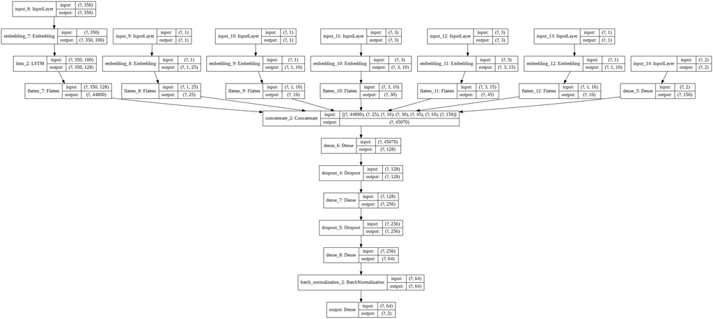

```python
#https://www.tensorflow.org/api_docs/python/tf/keras/utils/plot_model
tf.keras.utils.plot_model(
    Model1, to_file='model.png', show_shapes=True, show_layer_names=True,
    rankdir='TB', expand_nested=False, dpi=96
)
```

```python
#https://stackoverflow.com/questions/41032551/how-to-compute-receiving-operating-characteristic-roc-and-auc-in-keras
#https://stackoverflow.com/questions/45139163/roc-auc-score-only-one-class-present-in-y-true
import tensorflow as tf
from sklearn.metrics import roc_auc_score

def auc(y_true, y_pred):
  try:
    return tf.py_function(roc_auc_score, (y_true, y_pred), tf.double)
  except ValueError:
    pass
```

```python
#
from keras.callbacks import LearningRateScheduler
def lr_schedule(epoch):
    lrate = 0.01
    if epoch > 20:
        lrate*= 0.5e-3
    if epoch > 15:
        lrate*= 1e-3
    if epoch > 10:
        lrate *= 1e-2
    if epoch > 5:
        lrate *= 1e-1
    return lrate
```

```python
import datetime

!rm -rf ./logs/
log_dir="logs\\fit\\" + datetime.datetime.now().strftime("%Y%m%d-%H%M%S")
tensorboard_callback = keras.callbacks.TensorBoard(log_dir=log_dir,histogram_freq=0, write_graph=True,write_grads=True)
A=keras.optimizers.Adam(0.001)
# 0.01
R=keras.optimizers.RMSprop(learning_rate=0.001, rho=0.9)
Model1.compile(loss="categorical_crossentropy", optimizer=A, metrics=[auc])
```

```python
callback_list=[checkpoint,tensorboard_callback]
```

```python
train=[padded_docs_tr,padded_state_tr,padded_docs_grade_cat_tr,padded_docs_clean_cat_tr,padded_docs_clean_subcat_tr,padded_docs_teacher_tr,numericals_tr]
cv=[padded_docs_cv,padded_state_cv,padded_docs_grade_cat_cv,padded_docs_clean_cat_cv,padded_docs_clean_subcat_cv,padded_docs_teacher_cv,numericals_cv]
test=[padded_docs_ts,padded_state_ts,padded_docs_grade_cat_ts,padded_docs_clean_cat_ts,padded_docs_clean_subcat_ts,padded_docs_teacher_ts,numericals_ts]
```

```python
Model1.load_weights("/content/drive/My Drive/lstm for donorchoose/model1weights.hdf5")
```

```python
Model1.fit(train, y_train1, epochs=50, verbose=1,callbacks=callback_list,validation_data=(cv,y_cv1),use_multiprocessing=True,batch_size=500)
```

```
Train on 53531 samples, validate on 22942 samples

Epoch 00001: val_auc improved from 0.61567 to 0.62123, saving model to /content/drive/My Drive/lstm for donorchoose/model1weights.hdf5

Epoch 00002: val_auc improved from 0.62123 to 0.62731, saving model to /content/drive/My Drive/lstm for donorchoose/model1weights.hdf5

Epoch 00003: val_auc improved from 0.62731 to 0.63197, saving model to /content/drive/My Drive/lstm for donorchoose/model1weights.hdf5

Epoch 00004: val_auc did not improve from 0.63197

Epoch 00005: val_auc did not improve from 0.63197

Epoch 00006: val_auc improved from 0.63197 to 0.64911, saving model to /content/drive/My Drive/lstm for donorchoose/model1weights.hdf5

Epoch 00007: val_auc improved from 0.64911 to 0.65186, saving model to /content/drive/My Drive/lstm for donorchoose/model1weights.hdf5

Epoch 00008: val_auc improved from 0.65186 to 0.66718, saving model to /content/drive/My Drive/lstm for donorchoose/model1weights.hdf5

Epoch 00009: val_auc improved from 0.66718 to 0.67521, saving model to /content/drive/My Drive/lstm for donorchoose/model1weights.hdf5

Epoch 00010: val_auc improved from 0.67521 to 0.68001, saving model to /content/drive/My Drive/lstm for donorchoose/model1weights.hdf5

Epoch 00011: val_auc did not improve from 0.68001

Epoch 00012: val_auc did not improve from 0.68001

Epoch 00013: val_auc improved from 0.68001 to 0.68669, saving model to /content/drive/My Drive/lstm for donorchoose/model1weights.hdf5

Epoch 00014: val_auc did not improve from 0.68669

Epoch 00015: val_auc did not improve from 0.68669

Epoch 00016: val_auc improved from 0.68669 to 0.68780, saving model to /content/drive/My Drive/lstm for donorchoose/model1weights.hdf5

Epoch 00017: val_auc did not improve from 0.68780

Epoch 00018: val_auc did not improve from 0.68780

Epoch 00019: val_auc did not improve from 0.68780

Epoch 00020: val_auc did not improve from 0.68780

Epoch 00021: val_auc did not improve from 0.68780

Epoch 00022: val_auc did not improve from 0.68780

Epoch 00023: val_auc did not improve from 0.68780

Epoch 00024: val_auc did not improve from 0.68780

Epoch 00025: val_auc did not improve from 0.68780

Epoch 00026: val_auc did not improve from 0.68780
```

```python
%tensorboard --logdir logs\\fit\\20200525-053616
```

### Model-2

Use the same model as above but for 'input_seq_total_text_data' give only some words in the sentance not all the words. Filter the words as below.

```
1. Train the TF-IDF on the Train data feature 'essay'

2. Get the idf value for each word we have in the train data.

3. Remove the low idf value and high idf value words from our data. Do some analysis on the Idf values and based on those values choose the low and high threshold value. Because very frequent words and very very rare words don't give much information. (you can plot a box plots and take only the idf scores within IQR range and corresponding words)

4. Train the LSTM after removing the Low and High idf value words. (In model-1 Train on total data but in Model-2 train on data after removing some words based on IDF values)
```

```python
#https://stackoverflow.com/questions/48431173/is-there-a-way-to-get-only-the-idf-values-of-words-using-scikit-or-any-other-pyt
#get idf values
from sklearn.feature_extraction.text import TfidfVectorizer
vectorizer = TfidfVectorizer(use_idf=True)
vectorizer.fit(X_train['essay'].values)
```

```
TfidfVectorizer(analyzer='word', binary=False, decode_error='strict',
                dtype=<class 'numpy.float64'>, encoding='utf-8',
                input='content', lowercase=True, max_df=1.0, max_features=None,
                min_df=1, ngram_range=(1, 1), norm='l2', preprocessor=None,
                smooth_idf=True, stop_words=None, strip_accents=None,
                sublinear_tf=False, token_pattern='(?u)\\b\\w\\w+\\b',
                tokenizer=None, use_idf=True, vocabulary=None)
```

```python
idfs=vectorizer.idf_
words=vectorizer.get_feature_names()
```

```python
print(max(idfs))
print(min(idfs))
```

```
11.19488770435632
1.0070862452761777
```

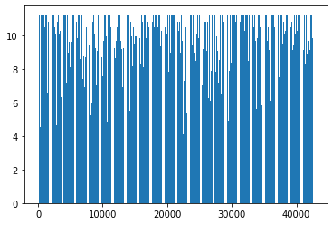

```python
import numpy as np
import matplotlib.pyplot as plt
y_pos=np.arange(len(words))
plt.bar(y_pos, idfs)

plt.show()
```

```python
#create a dataframe with words and idf values
import pandas as pd
idfdf=pd.DataFrame({'words':vectorizer.get_feature_names(),'idf':vectorizer.idf_})
idfdf = idfdf.sort_values(by ='idf' )
```

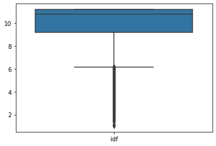

```python
import seaborn as sns
ax = sns.boxplot(data=idfdf)
```

Based on above plot, maximum threshold of 9 and min threshold of 3 can be considered.From box plot, most of the words are with idf values of >8.5 and <11. AS we want to removed most frequently occuring and less frequently occuring words, lets consider words with idf values less than 9 and and greater than 3

```python
#https://stackoverflow.com/questions/56156260/how-to-find-and-remove-words-which-have-low-and-high-idf-values
filtered_indices = np.argwhere(((idfs> 3) & (idfs<9) ))
filtered_indices = [idx[0] for idx in filtered_indices]


#preparing a set with filtered vocabulary
filtered_voc = {words[i] for i in filtered_indices}
```

```python
len(filtered_voc)
#convert set to list
filtered_voc_list=list(filtered_voc)
print(len(filtered_voc_list))
```

```
9861
```

```python
import tensorflow as tf
import keras
tk = keras.preprocessing.text.Tokenizer()
tk.fit_on_texts(filtered_voc_list)
vocab_size = len(tk.word_index) + 1
# integer encode the documents
encoded_docs_train=tk.texts_to_sequences(X_train['essay'])
encoded_docs_test=tk.texts_to_sequences(X_test['essay'])
encoded_docs_cv=tk.texts_to_sequences(X_cv['essay'])

max_length = 350
padded_docs_tr_m2 = keras.preprocessing.sequence.pad_sequences(encoded_docs_train, maxlen=max_length, padding='post')
padded_docs_ts_m2 = keras.preprocessing.sequence.pad_sequences(encoded_docs_test, maxlen=max_length, padding='post')
padded_docs_cv_m2 = keras.preprocessing.sequence.pad_sequences(encoded_docs_cv, maxlen=max_length, padding='post')
```

```python
print(padded_docs_tr_m2.shape)
print(padded_docs_ts_m2.shape)
print(padded_docs_cv_m2.shape)
```

```
(53531, 350)
(32775, 350)
(22942, 350)
```

```python
#using pretrain word embeddings
#load the entire GloVe word embedding file into memory as a dictionary of word to embedding array.
import numpy as np
embeddings_index = dict()
f = open('/content/drive/My Drive/CNN_with_textdata-20200413T094931Z-001/CNN_with_textdata/glove.6B/glove.6B.100d.txt')
for line in f:
	values = line.split()
	word = values[0]
	coefs = np.asarray(values[1:], dtype='float32')
	embeddings_index[word] = coefs
f.close()
print('Loaded %s word vectors.' % len(embeddings_index))
```

```
Loaded 400000 word vectors.
```

```python
# create a weight matrix for selected words in training docs
embedding_matrix = np.zeros((vocab_size, 100))
for word, i in tk.word_index.items():
	embedding_vector = embeddings_index.get(word)
	if embedding_vector is not None:
		embedding_matrix[i] = embedding_vector
```

```python
#build train,test and cv with new word list



Padded_data_tr=[padded_docs_tr_m2,padded_state_tr,padded_docs_grade_cat_tr,padded_docs_clean_cat_tr,padded_docs_clean_subcat_tr,padded_docs_teacher_tr,numericals_tr]
Padded_data_ts=[padded_docs_ts_m2,padded_state_ts,padded_docs_grade_cat_ts,padded_docs_clean_cat_ts,padded_docs_clean_subcat_ts,padded_docs_teacher_ts,numericals_ts]
Padded_data_cv=[padded_docs_cv_m2,padded_state_cv,padded_docs_grade_cat_cv,padded_docs_clean_cat_cv,padded_docs_clean_subcat_cv,padded_docs_teacher_cv,numericals_cv]
```

Build Model2

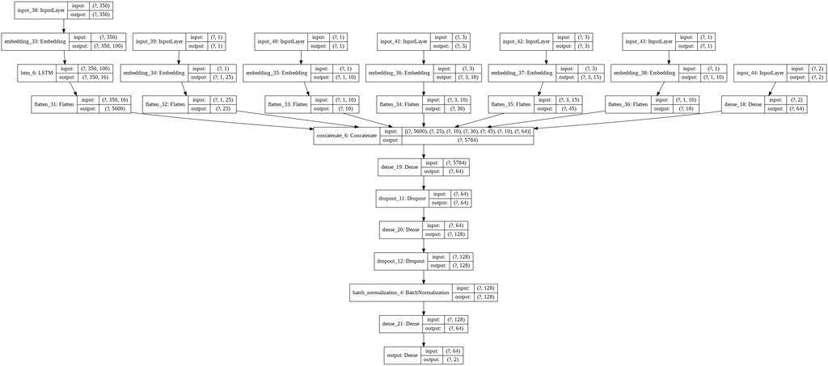

```python
#https://www.tensorflow.org/api_docs/python/tf/keras/utils/plot_model
tf.keras.utils.plot_model(
    Model2, to_file='model.png', show_shapes=True, show_layer_names=True,
    rankdir='TB', expand_nested=False, dpi=96
)
```

```python
# input_dim=Padded_data_tr.shape[1]
# Input_seq_total_text_data = Input(shape=(input_dim,))
# embeddinglayer = Embedding(vocab_size, 100, weights=[embedding_matrix], input_length=400, trainable=False)(Input_seq_total_text_data)
# lstm=LSTM(16,return_sequences=True)(embeddinglayer)
# flatten = Flatten()(lstm)
input_text_model2 = Input(shape=(350,))
embeddinglayer= Embedding(vocab_size, 100, weights=[embedding_matrix], input_length=350, trainable=False)(input_text_model2)
lstm = LSTM(16,return_sequences=True)(embeddinglayer)
flatten0 = Flatten()(lstm)



Input_school_state = Input(shape=(padded_state_tr.shape[1],))
embedding2 = Embedding(vocab_size_school_state, 25, input_length=1)(Input_school_state)
flatten2 = Flatten()(embedding2)

# Project_grade_category = Input(shape=(padded_docs_grade_cat_tr.shape[1],))
Project_grade_category = Input(shape=(1,))
embedding3 = Embedding(vocab_size_grade_cat, 10, input_length=1)(Project_grade_category)
flatten3 = Flatten()(embedding3)

Input_clean_categories  = Input(shape=(padded_docs_clean_cat_tr.shape[1],))
embedding4= Embedding(vocab_size_clean_cat, 10, input_length=3)(Input_clean_categories)
flatten4 = Flatten()(embedding4)

Input_clean_subcategories = Input(shape=(padded_docs_clean_subcat_tr.shape[1],))
embedding5 = Embedding(vocab_size_clean_subcat, 15, input_length=3)(Input_clean_subcategories)
flatten5 = Flatten()(embedding5)

Input_teacher_prefix = Input(shape=(padded_docs_teacher_tr.shape[1],))
embedding6 = Embedding(vocab_size_teacher, 10, input_length=1)(Input_teacher_prefix)
flatten6 = Flatten()(embedding6)

Input_remaining_teacher_number_of_previously_posted_projects_price = Input(shape=(2,))
dense_numerical = Dense(64,activation="relu")(Input_remaining_teacher_number_of_previously_posted_projects_price)

concatenate_layer=Concatenate(axis=1)([flatten0,flatten2,flatten3,flatten4,flatten5,flatten6,dense_numerical])
x = Dense(64,activation="relu",kernel_initializer="he_normal")(concatenate_layer)
x=Dropout(0.5)(x)
x = Dense(64,activation="relu",kernel_initializer="he_normal")(concatenate_layer)
x=Dropout(0.5)(x)
x = Dense(128,activation="relu",kernel_initializer="he_normal")(x)
x=Dropout(0.5)(x)
x = BatchNormalization()(x)
x = Dense(64,activation="relu", kernel_initializer="he_normal")(x)
# x=Dropout(0.5)(x)
output = Dense(2, activation='softmax', name='output')(x)
# Dense_layer1 = Dense(128,activation="relu")(concatenate_layer)
# # B1=BatchNormalization()(Dense_layer1)
# Droplayer1=Dropout(0.4)(Dense_layer1)
# Dense_layer2 = Dense(16,activation="relu")(Droplayer1)
# # B2=BatchNormalization()(Dense_layer2)
# Droplayer2=Dropout(0.2)(Dense_layer2)
# Dense_layer3 = Dense(16,activation="relu")(Droplayer2)
# Droplayer3=Dropout(0.3)(Dense_layer3)
# output = Dense(2, activation='softmax', name='output')(Droplayer3)

# Model1=Model((input,output))
Model2 = Model(inputs=[input_text_model2,Input_school_state,Project_grade_category,Input_clean_categories,Input_clean_subcategories,Input_teacher_prefix,Input_remaining_teacher_number_of_previously_posted_projects_price],outputs=output)
#
```

```python
#saving wts
# https://github.com/keras-team/keras/blob/master/examples/pretrained_word_embeddings.py
# https://machinelearningmastery.com/use-word-embedding-layers-deep-learning-keras/
from keras.callbacks import ModelCheckpoint

filepath="/content/drive/My Drive/lstm for donorchoose/model2weights.hdf5"
# filepath="/content/drive/My Drive/lstm for donorchoose/model2weights.hdf5"
checkpoint2 = ModelCheckpoint(filepath=filepath,monitor='val_auc',verbose=1,save_best_only=True,mode='max'
                             ,save_weights_only=True)
```

```python
from keras.callbacks import LearningRateScheduler
# def lr_schedule(epoch):
#     lrate = 0.01
#     if epoch > 20:
#         lrate*= 0.5e-3
#     if epoch > 15:
#         lrate*= 1e-3
#     if epoch > 10:
#         lrate *= 1e-2
#     if epoch > 5:
#         lrate *= 1e-1
#     return lrate


def lr_schedule(epoch):
    lrate = 0.01
    if epoch > 10:
        lrate*= 0.5e-3
    if epoch > 8:
        lrate*= 1e-3
    if epoch > 5:
        lrate *= 1e-2
    if epoch > 2:
        lrate *= 1e-1
    return lrate
```

```python
from tensorflow.keras.callbacks import ReduceLROnPlateau # specify the metric to monitor during training and reduce lr

rlrop = ReduceLROnPlateau(monitor='val_auc', factor=0.1, patience=1)
```

```python
import datetime

!rm -rf ./logs/
log_dir2="logs\\fit\\" + datetime.datetime.now().strftime("%Y%m%d-%H%M%S")
tensorboard_callback2 = keras.callbacks.TensorBoard(log_dir=log_dir2,histogram_freq=0, write_graph=True,write_grads=True)
#LearningRateScheduler(lr_schedule)

callback_list=[checkpoint2,tensorboard_callback2]
A=keras.optimizers.Adam()
# 0.01
R=keras.optimizers.RMSprop(learning_rate=0.001, rho=0.9)
Model2.compile(loss='categorical_crossentropy', optimizer=A,metrics=[auc])
```

```python
Model2.load_weights("/content/drive/My Drive/lstm for donorchoose/model2weights.hdf5")
```

```python
Model2.fit(Padded_data_tr, y_train1, epochs=50, verbose=1,callbacks=callback_list,validation_data=(Padded_data_cv,y_cv1),use_multiprocessing=True,batch_size=1000)
```

```
Train on 53531 samples, validate on 22942 samples
```

```
Epoch 00001: val_auc did not improve from 0.71677

Epoch 00002: val_auc did not improve from 0.71677

Epoch 00003: val_auc did not improve from 0.71677

Epoch 00004: val_auc did not improve from 0.71677

Epoch 00005: val_auc did not improve from 0.71677
```

[output not shown]

```python
%tensorboard --logdir logs\\fit\\20200516-135536
```

### Model-3

[figure not shown]

ref: https://i.imgur.com/fkQ8nGo.png

- **input_seq_total_text_data**:

  ```
    . Use text column('essay'), and use the Embedding layer to get word vectors.

    . Use given predefined glove word vectors, don't train any word vectors.

    . Use LSTM that is given above, get the LSTM output and Flatten that output.

    . You are free to preprocess the input text as you needed.
  ```

- **Other_than_text_data**:

  ```
    . Convert all your Categorical values to onehot coded and then concatenate all these onehot vectors

    . Neumerical values and use CNN1D as shown in above figure.

    . You are free to choose all CNN parameters like kernel sizes, stride.
  ```

```python
#http://queirozf.com/entries/one-hot-encoding-a-feature-on-a-pandas-dataframe-an-example

school_state_tr=pd.get_dummies(X_train['school_state'])
school_state_ts=pd.get_dummies(X_test['school_state'])
school_state_cv=pd.get_dummies(X_cv['school_state'])
```

```python
print(school_state_tr.shape)
print(school_state_ts.shape)
print(school_state_cv.shape)
```

```
(53531, 51)
(32775, 51)
(22942, 51)
```

```python
teacher_prefix_tr=pd.get_dummies(X_train['teacher_prefix'])
teacher_prefix_ts=pd.get_dummies(X_test['teacher_prefix'])
teacher_prefix_cv=pd.get_dummies(X_cv['teacher_prefix'])
```

```python
project_grade_category_tr=pd.get_dummies(X_train['project_grade_category'])
project_grade_category_ts=pd.get_dummies(X_test['project_grade_category'])
project_grade_category_cv=pd.get_dummies(X_cv['project_grade_category'])


clean_categories_tr=pd.get_dummies(X_train['clean_categories'])
clean_categories_ts=pd.get_dummies(X_test['clean_categories'])
clean_categories_cv=pd.get_dummies(X_cv['clean_categories'])


clean_subcategories_tr=pd.get_dummies(X_train['clean_subcategories'])
clean_subcategories_ts=pd.get_dummies(X_test['clean_subcategories'])
clean_subcategories_cv=pd.get_dummies(X_cv['clean_subcategories'])
```

```python
print(teacher_prefix_tr.shape)
print(teacher_prefix_ts.shape)
print(teacher_prefix_cv.shape)


print(project_grade_category_tr.shape)
print(project_grade_category_ts.shape)
print(project_grade_category_cv.shape)

print(clean_categories_tr.shape)
print(clean_categories_ts.shape)
print(clean_categories_cv.shape)

print(clean_subcategories_tr.shape)
print(clean_subcategories_ts.shape)
print(clean_subcategories_cv.shape)

print(numericals_tr.shape)
print(numericals_ts.shape)
print(numericals_cv.shape)
```

```
(53531, 5)
(32775, 5)
(22942, 5)
(53531, 4)
(32775, 4)
(22942, 4)
(53531, 50)
(32775, 50)
(22942, 49)
(53531, 382)
(32775, 358)
(22942, 347)
(53531, 2)
(32775, 2)
(22942, 2)
```

Its observed that there are columns or values subcategories that are present in train and not in test/cv. so marking those missing values as 0

```python
#https://stackoverflow.com/questions/41335718/keep-same-dummy-variable-in-training-and-testing-data
# Get missing columns in the training test
missing_cols = set( clean_subcategories_tr.columns ) - set( clean_subcategories_ts.columns )
# Add a missing column in test set with default value equal to 0
for c in missing_cols:
    clean_subcategories_ts[c] = 0
# Ensure the order of column in the test set is in the same order than in train set
clean_subcategories_ts = clean_subcategories_ts[clean_subcategories_tr.columns]
```

```python
#for cv
missing_cols = set( clean_subcategories_tr.columns ) - set( clean_subcategories_cv.columns )
# Add a missing column in test set with default value equal to 0
for c in missing_cols:
    clean_subcategories_cv[c] = 0
# Ensure the order of column in the test set is in the same order than in train set
clean_subcategories_cv = clean_subcategories_cv[clean_subcategories_tr.columns]
```

```python
missing_cols = set( clean_categories_tr.columns ) - set( clean_categories_ts.columns )
# Add a missing column in test set with default value equal to 0
for c in missing_cols:
    clean_categories_ts[c] = 0
# Ensure the order of column in the test set is in the same order than in train set
clean_categories_ts = clean_categories_ts[clean_categories_tr.columns]

missing_cols = set( clean_categories_tr.columns ) - set( clean_categories_cv.columns )
# Add a missing column in test set with default value equal to 0
for c in missing_cols:
    clean_categories_cv[c] = 0
# Ensure the order of column in the test set is in the same order than in train set
clean_categories_cv = clean_categories_cv[clean_categories_tr.columns]
```

```python
#concatenate
otherthan_text_train = np.concatenate((school_state_tr,teacher_prefix_tr,project_grade_category_tr,clean_categories_tr,clean_subcategories_tr,numericals_tr),axis=1)
otherthan_text_test = np.concatenate((school_state_ts,teacher_prefix_ts,project_grade_category_ts,clean_categories_ts,clean_subcategories_ts,numericals_ts),axis=1)
otherthan_text_cv = np.concatenate((school_state_cv,teacher_prefix_cv,project_grade_category_cv,clean_categories_cv,clean_subcategories_cv,numericals_cv),axis=1)
```

```python
print(otherthan_text_train.shape)
print(otherthan_text_test.shape)
print(otherthan_text_cv.shape)
```

```
(53531, 494)
(32775, 494)
(22942, 494)
```

```python
#was getting error
#ValueError: Input 0 of layer conv1d_2 is incompatible with the layer: expected ndim=3, found ndim=2. in model3. hence converting 2d to 3d for otherthan text data
from numpy import array, newaxis, expand_dims
otherthan_text_train1= expand_dims(otherthan_text_train, axis=2) #not_text_train[:, :, newaxis]
otherthan_text_test1= expand_dims(otherthan_text_test, axis=2) #not_text_test[:, :, newaxis]
otherthan_text_cv1= expand_dims(otherthan_text_cv, axis=2) #not_text_cv[:, :, newaxis]
```

```python
otherthan_text_train1.shape
```

[output not shown]

```python
train2 = [padded_docs_tr,otherthan_text_train1]
test2 = [padded_docs_ts,otherthan_text_test1]
cv2 = [padded_docs_cv,otherthan_text_cv1]
```

```python
padded_docs_cv.shape
```

```
(22942, 350)
```

Build model3

```python
# input_dim1=Padded_docs_tr.shape[1]
Input_seq_total_text_data = Input(shape=(350,))
embeddinglayer = Embedding(vocab_size, 100, weights=[embedding_matrix], input_length=350, trainable=False)(Input_seq_total_text_data)
lstm=LSTM(15,return_sequences=True)(embeddinglayer)
flattenm31 = Flatten()(lstm)

input_dim2=otherthan_text_train.shape[1]
Other_than_text_data=Input(shape=(input_dim2,1,))
conv1 = Conv1D(filters=16, kernel_size=2, activation='relu',padding="same",kernel_regularizer=regularizers.l2(0.001))(Other_than_text_data)
conv2 = Conv1D(filters=8, kernel_size=2, activation='relu',kernel_initializer="he_normal",padding="same",kernel_regularizer=keras.regularizers.l2(0.001))(conv1)
drop0=Dropout(0.3)(conv2)
flattenm32 = Flatten()(drop0)

concatenate = Concatenate(axis=1)([flattenm31,flattenm32])

Dense1 = Dense(18,activation="relu",kernel_initializer="he_normal")(concatenate)
drop1=Dropout(0.5)(Dense1)
Dense2 = Dense(10,activation="relu",kernel_initializer="he_normal")(drop1)
drop2=Dropout(0.5)(Dense2)
BN = BatchNormalization()(drop2)
Dense3 = Dense(9,activation="relu", kernel_initializer="he_normal")(BN)
output = Dense(2, activation='softmax', name='output')(Dense3)


model3 = Model(inputs=[Input_seq_total_text_data,Other_than_text_data],outputs=[output])
```

```python
model3.summary()
```

[output not shown]

[figure not shown]

```python
#https://www.tensorflow.org/api_docs/python/tf/keras/utils/plot_model
tf.keras.utils.plot_model(
    model3, to_file='model.png', show_shapes=True, show_layer_names=True,
    rankdir='TB', expand_nested=False, dpi=96
)
```

```python
from keras.utils import np_utils
Y_train1 = np_utils.to_categorical(y_train, 2)
Y_test1 = np_utils.to_categorical(y_test, 2)
Y_cv1 = np_utils.to_categorical(y_cv, 2)
```

```python
#saving wts
# https://github.com/keras-team/keras/blob/master/examples/pretrained_word_embeddings.py
# https://machinelearningmastery.com/use-word-embedding-layers-deep-learning-keras/
from keras.callbacks import ModelCheckpoint

filepath="/content/drive/My Drive/lstm for donorchoose/model4weights.hdf5"
# filepath="/content/drive/My Drive/lstm for donorchoose/model3weights.hdf5"
checkpoint3 = ModelCheckpoint(filepath=filepath,monitor='val_auc',verbose=1,save_best_only=True,mode='max'
                             ,save_weights_only=True)
```

```python
import datetime

!rm -rf ./logs/
log_dir3="logs\\fit\\" + datetime.datetime.now().strftime("%Y%m%d-%H%M%S")
tensorboard_callback3 = keras.callbacks.TensorBoard(log_dir=log_dir3,histogram_freq=0, write_graph=True,write_grads=True)

callback_list=[checkpoint3,earlystop,tensorboard_callback3]
A=tf.keras.optimizers.Adam(0.1)
model3.compile(loss='categorical_crossentropy', optimizer=A,metrics=[auc])
```

```python
model3.load_weights("/content/drive/My Drive/lstm for donorchoose/model3weights.hdf5")
```

```python
model3.fit(train2, Y_train1, epochs=10, verbose=1,callbacks=callback_list,validation_data=(cv2,Y_cv1),use_multiprocessing=True,batch_size=1000)
```

```
Train on 53531 samples, validate on 22942 samples

Epoch 00001: val_auc improved from -inf to 0.47491, saving model to /content/drive/My Drive/lstm for donorchoose/model4weights.hdf5

Epoch 00002: val_auc improved from 0.47491 to 0.53235, saving model to /content/drive/My Drive/lstm for donorchoose/model4weights.hdf5

Epoch 00003: val_auc did not improve from 0.53235

Epoch 00004: val_auc did not improve from 0.53235

Epoch 00005: val_auc did not improve from 0.53235

Epoch 00006: val_auc did not improve from 0.53235

Epoch 00007: val_auc did not improve from 0.53235
Epoch 00007: early stopping
```

```
<keras.callbacks.callbacks.History at 0x7f64d2f6c748>
```

```python
%tensorboard --logdir logs\\fit\\20200516-140819
```